# Linear_models

Zheyan

11/16/2021

# Model fitting

```r
data("nyc_airbnb")

nyc_airbnb =
  nyc_airbnb %>%
  mutate(stars = review_scores_location / 2) %>%
  rename(
    borough = neighbourhood_group,
    neighborhood = neighbourhood) %>%
  filter(borough != "Staten Island") %>%
  select(price, stars, borough, neighborhood, room_type)

nyc_airbnb
```

```
## # A tibble: 40,492 x 5
##    price stars borough neighborhood room_type
##    <dbl> <dbl> <chr>   <chr>        <chr>
##  1    99   5   Bronx   City Island  Private room
##  2   200  NA   Bronx   City Island  Private room
##  3   300  NA   Bronx   City Island  Entire home/apt
##  4   125   5   Bronx   City Island  Entire home/apt
##  5    69   5   Bronx   City Island  Private room
##  6   125   5   Bronx   City Island  Entire home/apt
##  7    85   5   Bronx   City Island  Entire home/apt
##  8    39   4.5 Bronx   Allerton     Private room
##  9    95   5   Bronx   Allerton     Entire home/apt
## 10   125   4.5 Bronx   Allerton     Entire home/apt
## # ... with 40,482 more rows
```

An good place to start is to consider price as an outcome that may depend on rating and borough. We fit that initial model in the following code.

```r
fit = lm(price ~ stars + borough, data = nyc_airbnb)
summary(fit)
```

```
##
## Call:
## lm(formula = price ~ stars + borough, data = nyc_airbnb)
##
## Residuals:
##    Min     1Q Median     3Q    Max
## -169.8  -64.0  -29.0   20.2 9870.0
##
## Coefficients:
##                  Estimate Std. Error t value Pr(>|t|)
## (Intercept)       -70.414     14.021  -5.022 5.14e-07 ***
## stars              31.990      2.527  12.657  < 2e-16 ***
## boroughBrooklyn    40.500      8.559   4.732 2.23e-06 ***
## boroughManhattan   90.254      8.567  10.534  < 2e-16 ***
## boroughQueens      13.206      9.065   1.457    0.145
## ---
## Signif. codes:  0 '***' 0.001 '**' 0.01 '*' 0.05 '.' 0.1 ' ' 1
##
## Residual standard error: 181.5 on 30525 degrees of freedom
##   (9962 observations deleted due to missingness)
## Multiple R-squared:  0.03423,    Adjusted R-squared:  0.03411
## F-statistic: 270.5 on 4 and 30525 DF,  p-value: < 2.2e-16
```

The lm function begins with the formula specification – outcome on the left of the ~ and predictors separated by + on the right. As we’ll see shortly, interactions between variables can be specified using *. You can also specify an intercept-only model (outcome ~ 1), a model with no intercept (outcome ~ 0 + …), and a model using all available predictors (outcome ~ .).

R will treat categorical (factor) covariates appropriately and predictably: indicator variables are created for each non-reference category and included in your model, and the factor level is treated as the reference. As with ggplot, being careful with factors is therefore critical!

```r
nyc_airbnb =
  nyc_airbnb %>%
  mutate(
    borough = fct_infreq(borough),
    room_type = fct_infreq(room_type))


fit = lm(price ~ stars + borough, data = nyc_airbnb)
summary(fit)
```

```
##
## Call:
## lm(formula = price ~ stars + borough, data = nyc_airbnb)
##
## Residuals:
##    Min     1Q Median     3Q    Max
## -169.8  -64.0  -29.0   20.2 9870.0
##
## Coefficients:
##                 Estimate Std. Error t value Pr(>|t|)
## (Intercept)       19.839     12.189   1.628    0.104
## stars             31.990      2.527  12.657   <2e-16 ***
## boroughBrooklyn  -49.754      2.235 -22.262   <2e-16 ***
## boroughQueens    -77.048      3.727 -20.675   <2e-16 ***
## boroughBronx     -90.254      8.567 -10.534   <2e-16 ***
## ---
## Signif. codes:  0 '***' 0.001 '**' 0.01 '*' 0.05 '.' 0.1 ' ' 1
##
## Residual standard error: 181.5 on 30525 degrees of freedom
##   (9962 observations deleted due to missingness)
## Multiple R-squared:  0.03423,    Adjusted R-squared:  0.03411
## F-statistic: 270.5 on 4 and 30525 DF,  p-value: < 2.2e-16
```

If you want to present sth….

```r
fit %>%
  broom::tidy() %>%
  mutate(term = str_replace(term, 'borough', 'Borough:')) %>%
  select(term, estimate, p.value)
```

```
## # A tibble: 5 x 3
##   term             estimate   p.value
##   <chr>               <dbl>     <dbl>
## 1 (Intercept)          19.8 1.04e-  1
## 2 stars                32.0 1.27e- 36
## 3 Borough:Brooklyn    -49.8 6.32e-109
## 4 Borough:Queens      -77.0 2.58e- 94
## 5 Borough:Bronx       -90.3 6.64e- 26
```

It’s important to note that changing reference categories won’t change “fit” or statistical sigificance, but can affect ease of interpretation.

# Diagnosis

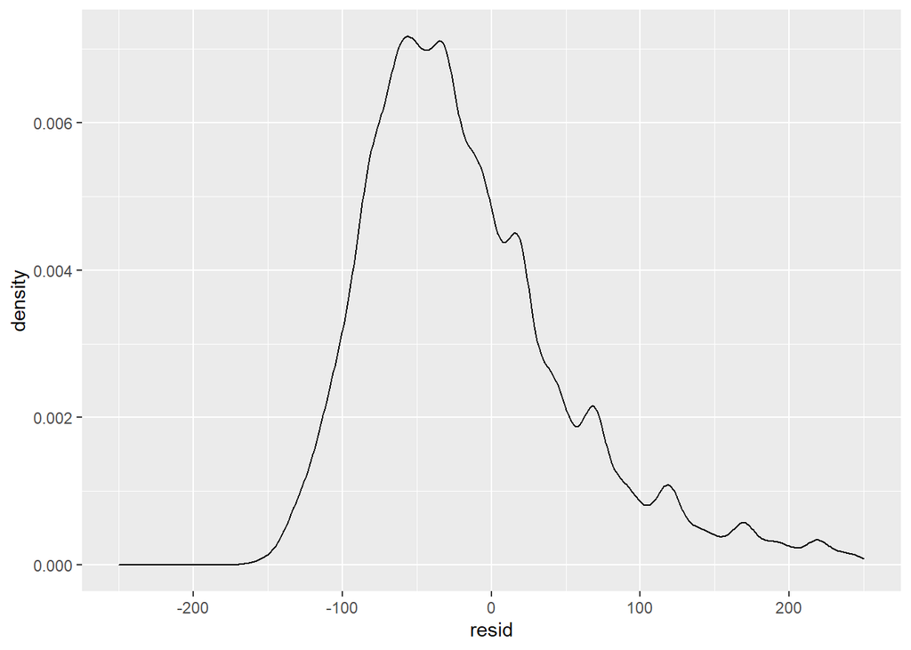

```r
modelr::add_residuals(nyc_airbnb, fit) %>%
  ggplot(aes(x = resid)) +
  geom_density() +
  xlim(-250, 250)
```

## Interactions? Nesting?

```r
nyc_airbnb %>%
  lm(price ~ stars * borough + room_type * borough, data = .) %>%
  broom::tidy() %>%
  knitr::kable(digits = 3)
```

| term | estimate | std.error | statistic | p.value |
| --- | --- | --- | --- | --- |
| (Intercept) | 95.694 | 19.184 | 4.988 | 0.000 |
| stars | 27.110 | 3.965 | 6.838 | 0.000 |
| boroughBrooklyn | -26.066 | 25.080 | -1.039 | 0.299 |
| boroughQueens | -4.118 | 40.674 | -0.101 | 0.919 |
| boroughBronx | -5.627 | 77.808 | -0.072 | 0.942 |
| room_typePrivate room | -124.188 | 2.996 | -41.457 | 0.000 |
| room_typeShared room | -153.635 | 8.692 | -17.676 | 0.000 |
| stars:boroughBrooklyn | -6.139 | 5.237 | -1.172 | 0.241 |
| stars:boroughQueens | -17.455 | 8.539 | -2.044 | 0.041 |
| stars:boroughBronx | -22.664 | 17.099 | -1.325 | 0.185 |
| boroughBrooklyn:room_typePrivate room | 31.965 | 4.328 | 7.386 | 0.000 |
| boroughQueens:room_typePrivate room | 54.933 | 7.459 | 7.365 | 0.000 |
| boroughBronx:room_typePrivate room | 71.273 | 18.002 | 3.959 | 0.000 |
| boroughBrooklyn:room_typeShared room | 47.797 | 13.895 | 3.440 | 0.001 |
| boroughQueens:room_typeShared room | 58.662 | 17.897 | 3.278 | 0.001 |
| boroughBronx:room_typeShared room | 83.089 | 42.451 | 1.957 | 0.050 |

Try nesting

```r
nest_lm_res =
  nyc_airbnb %>%
  nest(data = -borough) %>%
  mutate(
    models = map(data, ~lm(price ~ stars + room_type, data = .x)),
    results = map(models, broom::tidy)) %>%
  select(-data, -models) %>%
  unnest(results)


nest_lm_res
```

```
## # A tibble: 16 x 6
##    borough   term                  estimate std.error statistic   p.value
##    <fct>     <chr>                    <dbl>     <dbl>     <dbl>     <dbl>
##  1 Bronx     (Intercept)              90.1      15.2       5.94 5.73e-  9
##  2 Bronx     stars                     4.45      3.35      1.33 1.85e-  1
##  3 Bronx     room_typePrivate room   -52.9       3.57    -14.8  6.21e- 41
##  4 Bronx     room_typeShared room    -70.5       8.36     -8.44 4.16e- 16
##  5 Queens    (Intercept)              91.6      25.8       3.54 4.00e-  4
##  6 Queens    stars                     9.65      5.45      1.77 7.65e-  2
##  7 Queens    room_typePrivate room   -69.3       4.92    -14.1  1.48e- 43
##  8 Queens    room_typeShared room    -95.0      11.3      -8.43 5.52e- 17
##  9 Brooklyn  (Intercept)              69.6      14.0       4.96 7.27e-  7
## 10 Brooklyn  stars                    21.0       2.98      7.05 1.90e- 12
## 11 Brooklyn  room_typePrivate room   -92.2       2.72    -34.0  6.40e-242
## 12 Brooklyn  room_typeShared room   -106.        9.43    -11.2  4.15e- 29
## 13 Manhattan (Intercept)              95.7      22.2       4.31 1.62e-  5
## 14 Manhattan stars                    27.1       4.59      5.91 3.45e-  9
## 15 Manhattan room_typePrivate room  -124.        3.46    -35.8  9.40e-270
## 16 Manhattan room_typeShared room   -154.       10.1     -15.3  2.47e- 52
```

Show model result of nesting data

```r
nest_lm_res %>%
  select(borough, term, estimate) %>%
  mutate(term = fct_inorder(term)) %>%
  pivot_wider(
    names_from = term, values_from = estimate) %>%
  knitr::kable(digits = 3)
```

| borough | (Intercept) | stars | room_typePrivate room | room_typeShared room |
| --- | --- | --- | --- | --- |
| Bronx | 90.067 | 4.446 | -52.915 | -70.547 |
| Queens | 91.575 | 9.654 | -69.255 | -94.973 |
| Brooklyn | 69.627 | 20.971 | -92.223 | -105.839 |
| Manhattan | 95.694 | 27.110 | -124.188 | -153.635 |

```r
manhattan_airbnb =
  nyc_airbnb %>%
  filter(borough == "Manhattan")

manhattan_nest_lm_res =
  manhattan_airbnb %>%
  nest(data = -neighborhood) %>%
  mutate(
    models = map(data, ~lm(price ~ stars + room_type, data = .x)),
    results = map(models, broom::tidy)) %>%
  select(-data, -models) %>%
  unnest(results)

manhattan_nest_lm_res
```

```
## # A tibble: 123 x 6
##    neighborhood      term                  estimate std.error statistic  p.value
##    <chr>             <chr>                    <dbl>     <dbl>     <dbl>    <dbl>
##  1 Battery Park City (Intercept)             -119.      366.     -0.324 7.48e- 1
##  2 Battery Park City stars                     74.0      74.2     0.997 3.27e- 1
##  3 Battery Park City room_typePrivate room   -126.       27.6    -4.56  8.11e- 5
##  4 Battery Park City room_typeShared room    -160.       56.3    -2.84  7.96e- 3
##  5 Chinatown         (Intercept)              337.       60.4     5.59  5.66e- 8
##  6 Chinatown         stars                    -27.8      13.0    -2.14  3.34e- 2
##  7 Chinatown         room_typePrivate room   -109.       11.5    -9.52  1.03e-18
##  8 Chinatown         room_typeShared room    -143.       93.2    -1.54  1.25e- 1
##  9 Chelsea           (Intercept)              477.      135.      3.53  4.38e- 4
## 10 Chelsea           stars                    -44.5      27.3    -1.63  1.04e- 1
## # ... with 113 more rows
```

Look at neighborhoods in Manhattan …

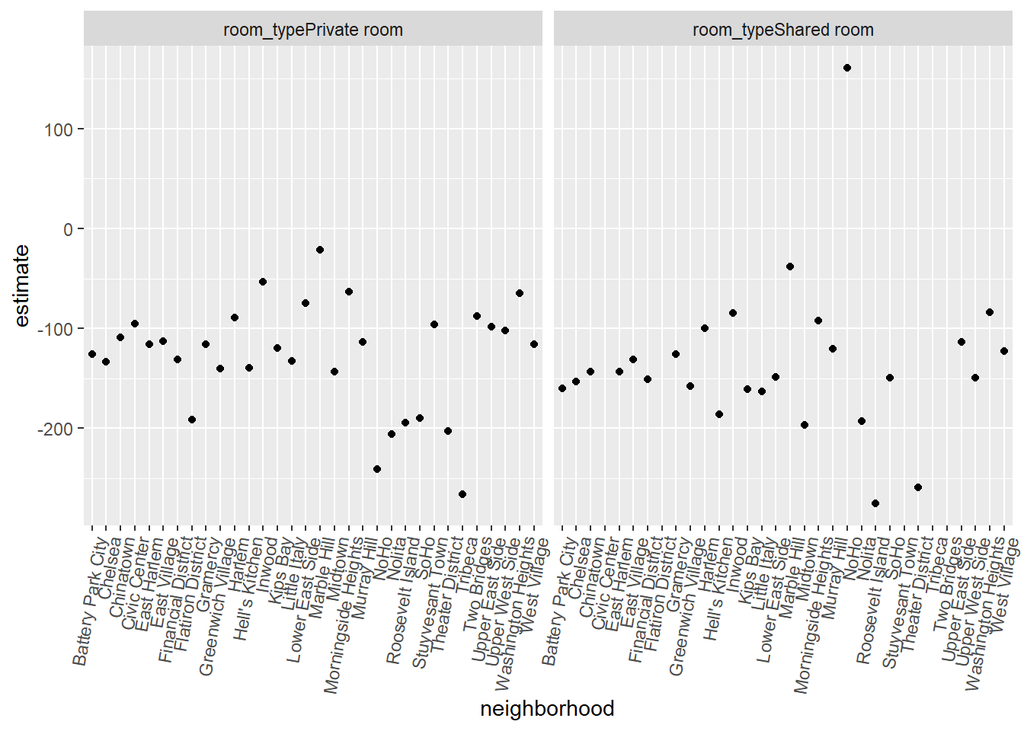

```r
manhattan_nest_lm_res %>%
  filter(str_detect(term, "room_type")) %>%
  ggplot(aes(x = neighborhood, y = estimate)) +
  geom_point() +
  facet_wrap(~term) +
  theme(axis.text.x = element_text(angle = 80, hjust = 1))
```